# Sim_HW3

Alex Blohm

9/26/2019

```r
library(tidyverse)
```

# 1.

Chapter 9, Exercise 4

```r
log_1plusx <- function(x, error_thresh){
i  <- 2; csum <- x; last_term <- x
while (abs(last_term) > error_thresh){
last_term <- ((-1)^(i-1)*x^i)/i
csum <-csum + last_term
i <- i + 1
}

return(c(i-1, csum))
}

log_1plusx(x=.5, error_thresh = 10^(-16))
```

```
## [1] 48.0000000  0.4054651
```

```r
#log(1.5)
```

48 terms, because I started at 2…!

## Attempt 1- Failure

$$log(2)=log(\sqrt4)=log((\sqrt{1+3})=1/2log(1+3)$$

```r
#log_1plusx(x=1, error_thresh = 10^(-16)) will not finish
#1/2*log_1plusx(x=3, error_thresh = 10^(-16))
```

welp, that failed…

## Attempt 2- Success

$$log(2)=log(\sqrt2^2)=2log(\sqrt2)=2log(1+(\sqrt2 - 1))$$

```r
2*log_1plusx(x=sqrt(2)-1, error_thresh = 10^(-16))[2]
```

```
## [1] 0.6931472
```

```r
log(2)
```

```
## [1] 0.6931472
```

```r
#Number of terms:
log_1plusx(x=sqrt(2)-1, error_thresh = 10^(-16))[1]
```

```
## [1] 38
```

WOOO FINALLY!

# 2.

Chapter 9, Exercise 5

The first formula requires a difference and an exponent inside the the summation, while the second function does the summation first (so you don’t need to multiply the number operations).

I am guessing the first function is 2n operations and the second is one n.

# 3.

Chapter 9, Exercise 9

```r
conv <- function(x,y){
n <- length(x)
z <- rep(0, 2*n)
for (k in (1:(2*n))){
  low <- max(1, k-n+1)
  high <- min(k,n)
  for (i in (low:high)){
    z[k] <- z[k] + x[i]*y[k-i+1]
  }
}
return(z)
}

x1 <- c(1:100)
y1 <- c(1:100)
str <- Sys.time()
conv(x1,y1)
```

```
##   [1]      1      4     10     20     35     56     84    120    165    220
##  [11]    286    364    455    560    680    816    969   1140   1330   1540
##  [21]   1771   2024   2300   2600   2925   3276   3654   4060   4495   4960
##  [31]   5456   5984   6545   7140   7770   8436   9139   9880  10660  11480
##  [41]  12341  13244  14190  15180  16215  17296  18424  19600  20825  22100
##  [51]  23426  24804  26235  27720  29260  30856  32509  34220  35990  37820
##  [61]  39711  41664  43680  45760  47905  50116  52394  54740  57155  59640
##  [71]  62196  64824  67525  70300  73150  76076  79079  82160  85320  88560
##  [81]  91881  95284  98770 102340 105995 109736 113564 117480 121485 125580
##  [91] 129766 134044 138415 142880 147440 152096 156849 161700 166650 171700
## [101] 176649 181496 186240 190880 195415 199844 204166 208380 212485 216480
## [111] 220364 224136 227795 231340 234770 238084 241281 244360 247320 250160
## [121] 252879 255476 257950 260300 262525 264624 266596 268440 270155 271740
## [131] 273194 274516 275705 276760 277680 278464 279111 279620 279990 280220
## [141] 280309 280256 280060 279720 279235 278604 277826 276900 275825 274600
## [151] 273224 271696 270015 268180 266190 264044 261741 259280 256660 253880
## [161] 250939 247836 244570 241140 237545 233784 229856 225760 221495 217060
## [171] 212454 207676 202725 197600 192300 186824 181171 175340 169330 163140
## [181] 156769 150216 143480 136560 129455 122164 114686 107020  99165  91120
## [191]  82884  74456  65835  57020  48010  38804  29401  19800  10000     NA
```

```r
stp <- Sys.time()
stp-str
```

```
## Time difference of 0.0132699 secs
```

```r
conv2 <- function(x,y){
z <- convolve(x,rev(y), type="o")
return(z)
}


str <- Sys.time()
conv2(x1,y1)
```

```
##   [1]      1      4     10     20     35     56     84    120    165    220
##  [11]    286    364    455    560    680    816    969   1140   1330   1540
##  [21]   1771   2024   2300   2600   2925   3276   3654   4060   4495   4960
##  [31]   5456   5984   6545   7140   7770   8436   9139   9880  10660  11480
##  [41]  12341  13244  14190  15180  16215  17296  18424  19600  20825  22100
##  [51]  23426  24804  26235  27720  29260  30856  32509  34220  35990  37820
##  [61]  39711  41664  43680  45760  47905  50116  52394  54740  57155  59640
##  [71]  62196  64824  67525  70300  73150  76076  79079  82160  85320  88560
##  [81]  91881  95284  98770 102340 105995 109736 113564 117480 121485 125580
##  [91] 129766 134044 138415 142880 147440 152096 156849 161700 166650 171700
## [101] 176649 181496 186240 190880 195415 199844 204166 208380 212485 216480
## [111] 220364 224136 227795 231340 234770 238084 241281 244360 247320 250160
## [121] 252879 255476 257950 260300 262525 264624 266596 268440 270155 271740
## [131] 273194 274516 275705 276760 277680 278464 279111 279620 279990 280220
## [141] 280309 280256 280060 279720 279235 278604 277826 276900 275825 274600
## [151] 273224 271696 270015 268180 266190 264044 261741 259280 256660 253880
## [161] 250939 247836 244570 241140 237545 233784 229856 225760 221495 217060
## [171] 212454 207676 202725 197600 192300 186824 181171 175340 169330 163140
## [181] 156769 150216 143480 136560 129455 122164 114686 107020  99165  91120
## [191]  82884  74456  65835  57020  48010  38804  29401  19800  10000
```

```r
stp <- Sys.time()
stp-str
```

```
## Time difference of 0.002453089 secs
```

This was quicker!

# 4

Question 10. Use the system.time function to compare the relative time that it takes to perform addition, multiplication, powers, and other simple operations. You may wish to perform each more than once! Perform each operation 1000 times and store the time it takes to run each. Then compare the distributions of each.)

```r
out <- c(NA,NA)
addition <- function(x){
  for (i in 1:length(x)) {
    out[i] <- x[i] + 10
  }
#return (out)
}

inp <- c(1:1000)
addition(inp)
str <- Sys.time()
addition(inp)
stp <- Sys.time()
stp-str
```

```
## Time difference of 0.001521111 secs
```

```r
mult <- function(x){
  for (i in 1:length(x)) {
    out[i] <- x[i] * 10
  }
#return (out)
}

str <- Sys.time()
mult(inp)
stp <- Sys.time()
stp-str
```

```
## Time difference of 0.004310846 secs
```

```r
exp <- function(x){
  for (i in 1:length(x)) {
    out[i] <- x[i] ^ 10
  }
#return (out)
}

str <- Sys.time()
exp(inp)
stp <- Sys.time()
stp-str
```

```
## Time difference of 0.00388217 secs
```

# 5.

Chapter 10, Exercise 3. (These functions are in the pacakge “spuRs”)

```r
library(spuRs)
fixedpoint(ftn = cos, x0 = 0)
```

```
## At iteration 1 value of x is: 1
## At iteration 2 value of x is: 0.5403023
## At iteration 3 value of x is: 0.8575532
## At iteration 4 value of x is: 0.6542898
## At iteration 5 value of x is: 0.7934804
## At iteration 6 value of x is: 0.7013688
## At iteration 7 value of x is: 0.7639597
## At iteration 8 value of x is: 0.7221024
## At iteration 9 value of x is: 0.7504178
## At iteration 10 value of x is: 0.731404
## At iteration 11 value of x is: 0.7442374
## At iteration 12 value of x is: 0.7356047
## At iteration 13 value of x is: 0.7414251
## At iteration 14 value of x is: 0.7375069
## At iteration 15 value of x is: 0.7401473
## At iteration 16 value of x is: 0.7383692
## At iteration 17 value of x is: 0.7395672
## At iteration 18 value of x is: 0.7387603
## At iteration 19 value of x is: 0.7393039
## At iteration 20 value of x is: 0.7389378
## At iteration 21 value of x is: 0.7391844
## At iteration 22 value of x is: 0.7390183
## At iteration 23 value of x is: 0.7391302
## At iteration 24 value of x is: 0.7390548
## At iteration 25 value of x is: 0.7391056
## At iteration 26 value of x is: 0.7390714
## At iteration 27 value of x is: 0.7390944
## At iteration 28 value of x is: 0.7390789
## At iteration 29 value of x is: 0.7390893
## At iteration 30 value of x is: 0.7390823
## At iteration 31 value of x is: 0.739087
## At iteration 32 value of x is: 0.7390838
## At iteration 33 value of x is: 0.739086
## At iteration 34 value of x is: 0.7390845
## At iteration 35 value of x is: 0.7390855
## At iteration 36 value of x is: 0.7390849
## At iteration 37 value of x is: 0.7390853
## At iteration 38 value of x is: 0.739085
## At iteration 39 value of x is: 0.7390852
## At iteration 40 value of x is: 0.7390851
## At iteration 41 value of x is: 0.7390852
## At iteration 42 value of x is: 0.7390851
## At iteration 43 value of x is: 0.7390851
## At iteration 44 value of x is: 0.7390851
## At iteration 45 value of x is: 0.7390851
## At iteration 46 value of x is: 0.7390851
## At iteration 47 value of x is: 0.7390851
## At iteration 48 value of x is: 0.7390851
## At iteration 49 value of x is: 0.7390851
## At iteration 50 value of x is: 0.7390851
## At iteration 51 value of x is: 0.7390851
## At iteration 52 value of x is: 0.7390851
## At iteration 53 value of x is: 0.7390851
## Algorithm converged
```

```
## [1] 0.7390851
```

```r
f <- function(x){
 fx <- cos(x)-x
 dfx <- -sin(x)-1
 return(c(fx, dfx))
}
newtonraphson(ftn = f, x0 = 0)
```

```
## At iteration 1 value of x is: 1
## At iteration 2 value of x is: 0.7503639
## At iteration 3 value of x is: 0.7391129
## At iteration 4 value of x is: 0.7390851
## Algorithm converged
```

```
## [1] 0.7390851
```

# 6.

Chapter 10, Exercise 10.

## a.

```r
f <- function(x){
 fx <- sin(x)
 dfx <- cos(x)
 return(c(fx, dfx))
}
newtonraphson(ftn = f, x0 = 3)
```

```
## At iteration 1 value of x is: 3.142547
## At iteration 2 value of x is: 3.141593
## Algorithm converged
```

```
## [1] 3.141593
```

## b

```r
f <- function(x, n = 10){
  sum <- 0
    for(k in 0:n){
      out <- ((-1)^k*(x^(2*k+1)))/(factorial(2*k + 1))
      sum <- sum + out
    }
  return(sum)
}
f(1,5)
```

```
## [1] 0.841471
```

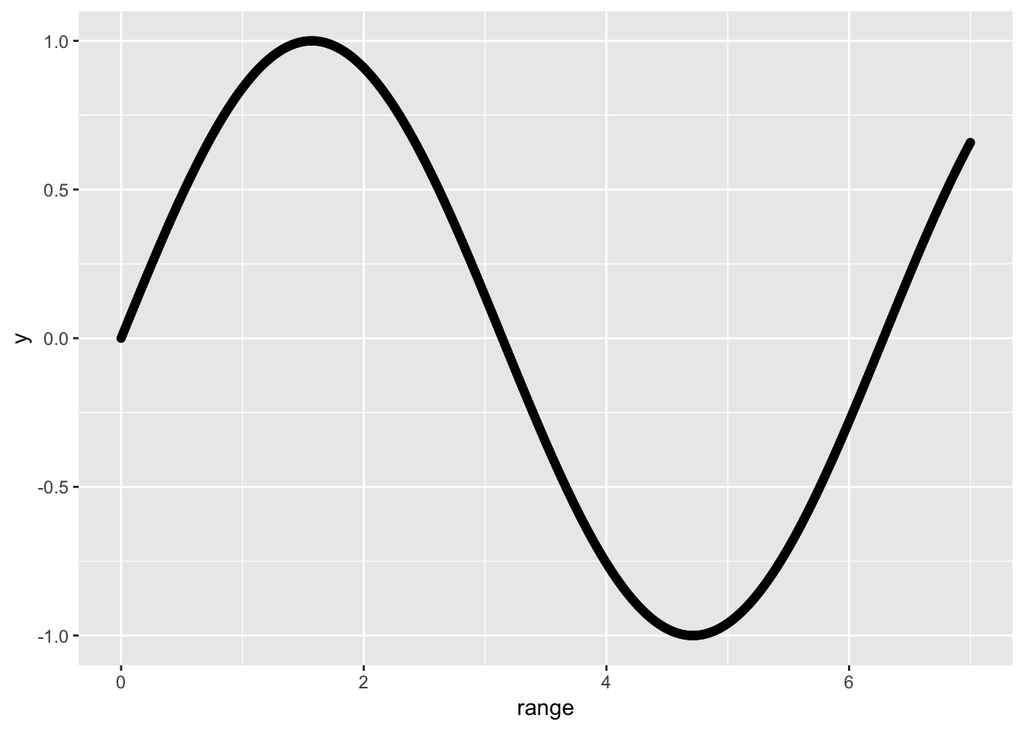

```r
range <- seq(0,7,.01)

y <- range %>% map_dbl(f)
data <- data.frame(range, y)
ggplot(data, aes(x=range, y=y)) + geom_point()
```

```r
k=1;x=1
(-1)^k*(x^(2*k+1))/factorial(2*k + 1)
```

```
## [1] -0.1666667
```

```r
#secant_meth first 2 rounds
3.1-f(3.1)*(3.1-3)/(f(3.1) - f(3))
```

```
## [1] 3.141773
```

```r
1.56726-f(1.56726)*(1.56726 - 3.1)/(f(1.56726) - f(3.1))
```

```
## [1] 3.166498
```

```r
f
```

```
## function(x, n = 10){
##   sum <- 0
##     for(k in 0:n){
##       out <- ((-1)^k*(x^(2*k+1)))/(factorial(2*k + 1))
##       sum <- sum + out
##     }
##   return(sum)
## }
## <bytecode: 0x7f87d0962bd0>
```

```r
secant_meth <- function(x0, x1, f, n=10){
  x <- c(x0, x1, rep(NA, n))
  for (i in (2:n)){
        x[i+1] <- x[i] - f(x[i])*(x[i]-x[i-1])/(f(x[i])-f(x[i-1]))
        print(x[i+1])
}
      return(x[n])
}
secant_meth(3,3.1, f)
```

```
## [1] 3.141773
## [1] 3.141593
## [1] 3.141593
## [1] 3.141593
## [1] 3.141593
## [1] 3.141593
## [1] NaN
## [1] NaN
## [1] NaN
```

```
## [1] NaN
```

# 7.

(Grad Only) Use the Newton-Raphson algorithm to find the roots of the following function (there are 3 roots): f (x) = x3 − 1957x2 + 1187296x − 210305472

```r
f <- function(x){
  fx <- x^3 - 1957*x^2 + 1187296*x - 210305472
  dfx <- 3*x^2 - 2*1957*x + 1187296
  return(c(fx, dfx))
}
newtonraphson(f, x0 = 0)
```

```
## At iteration 1 value of x is: 177.1298
## At iteration 2 value of x is: 272.0797
## At iteration 3 value of x is: 306.907
## At iteration 4 value of x is: 311.9004
## At iteration 5 value of x is: 312
## At iteration 6 value of x is: 312
## At iteration 7 value of x is: 312
## Algorithm converged
```

```
## [1] 312
```

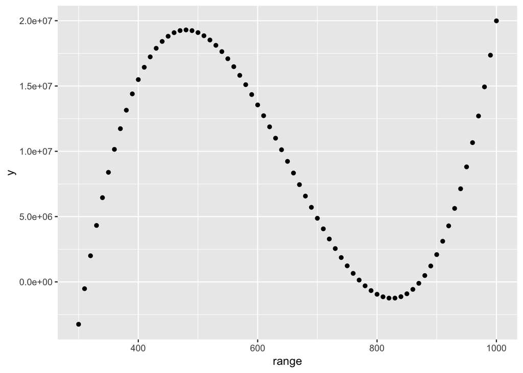

```r
f1 <- function(x){
  fx <- x^3 - 1957*x^2 + 1187296*x - 210305472
  return(fx)
}
range <- seq(300,1000, 10)
y <- range %>% map_dbl(f1)
dat <- data.frame(range, y)
ggplot(dat, aes(x=range, y)) + geom_point()
```

```r
newtonraphson(f, x0 = 850)
```

```
## At iteration 1 value of x is: 882.6703
## At iteration 2 value of x is: 873.109
## At iteration 3 value of x is: 872.0143
## At iteration 4 value of x is: 872
## At iteration 5 value of x is: 872
## At iteration 6 value of x is: 872
## Algorithm converged
```

```
## [1] 872
```

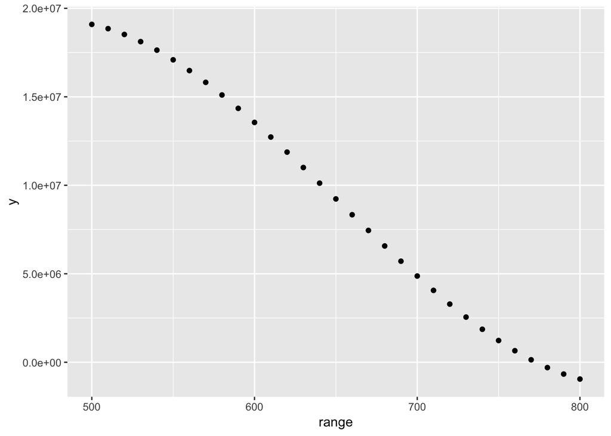

```r
range <- seq(500,800, 10)
y <- range %>% map_dbl(f1)
dat <- data.frame(range, y)
ggplot(dat, aes(x=range, y)) + geom_point()
```

```r
newtonraphson(f, x0 = 760)
```

```
## At iteration 1 value of x is: 771.9589
## At iteration 2 value of x is: 772.9916
## At iteration 3 value of x is: 773
## At iteration 4 value of x is: 773
## Algorithm converged
```

```
## [1] 773
```